# Predicting Hospital Exit

Catherine and Gi’s project

Preliminary predictions

Catherine Ishitani , Gi Kim (Wharton)  
March 31, 2021

## Lasso

Lasso model performs poorly, as there is no distinction of the spread in predicted probability between exited and non-exited outcome.

```
[1] 0.003981072
```

```
[1] 0.1249752
```

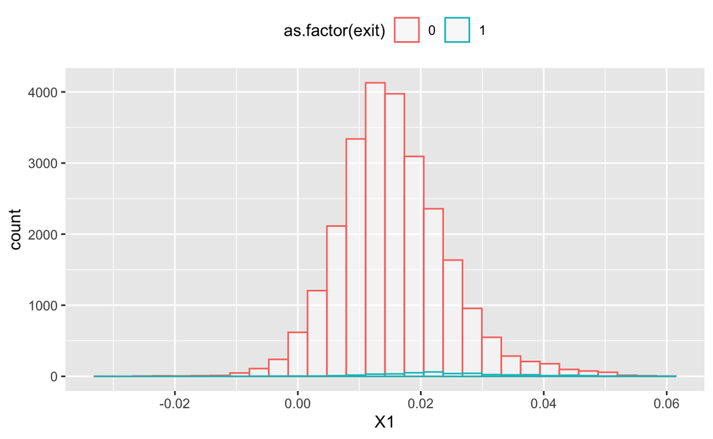

## Decision tree

Classification trees generally perform poorly on rare event (e.g., hospital exit) data. We tried oversampling our minority events using SMOTE techniques, but found that performance was still better using a regression tree. SMOTE did not enhance our regression tree performance, so we ran the remaining models using our original dataset.

We created training and test samples.

```r
# Create reproducible training (70%) and test (30%) sets.
set.seed(123)
hosp_split <- initial_split(syndata, prop = .7)
hosp_train <- training(hosp_split)
hosp_test  <- testing(hosp_split)
```

Then, we ran a tree using the CART algorithm on the training sample.

```r
#Our CART code is based on Professor Gandhi's from lecture.
m1 <- rpart(
  formula = exit_outcome ~ .,
  data    = hosp_train,
  method  = "anova"
  )

m1
```

```
n= 60068

node), split, n, deviance, yval
      * denotes terminal node

1) root 60068 949.4972 0.01606513
  2) l2_tot_assets>=-2.27342 59987 905.8903 0.01533666
    4) ni_mgn>=-0.126334 56840 694.3053 0.01236805 *
    5) ni_mgn< -0.126334 3147 202.0369 0.06895456 *
  3) l2_tot_assets< -2.27342 81  20.0000 0.55555560 *
```

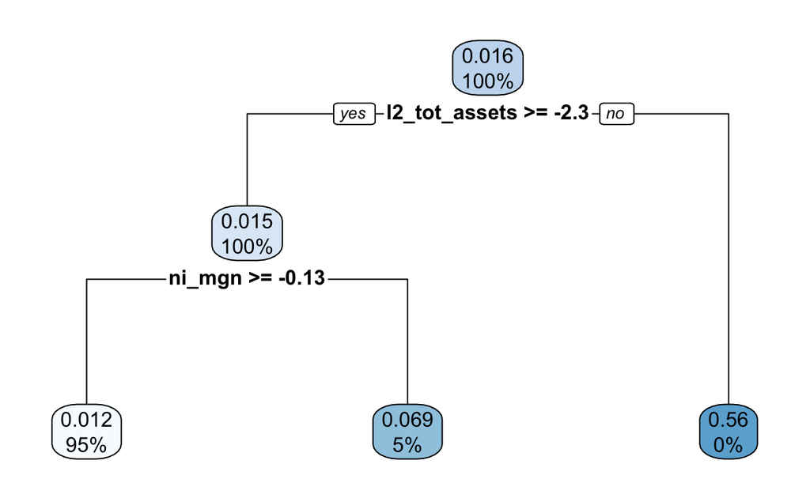

```r
rpart.plot(m1)
```

```r
#rpart.plot(m1,box.palette = "blue")
```

Our cross validation plot indicates that the optimal tree only has 2 splits. A lagged measure of total assets is split first (a proxy for size), followed by net income margin.

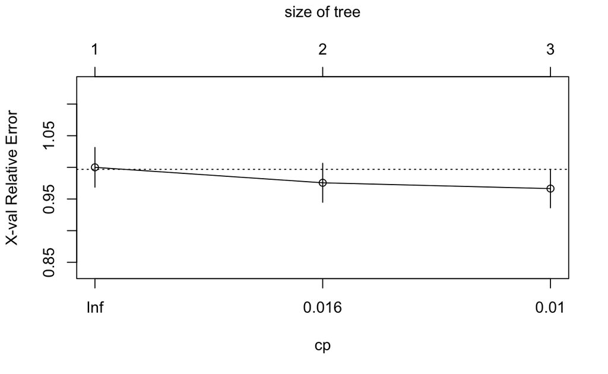

```r
plotcp(m1)
```

Our predicted test error is ~12.1%. (As an aside, visualizing prediction performance for binary variables is awkward. Our plot indicates that our model predicts at most a 56% probability of exit for any observation and is much more successful at predicting non-exit.)

```r
pred <- predict(m1, newdata = hosp_test)
p_error <- Metrics::rmse(actual = hosp_test$exit_outcome, predicted = pred)
p_error
```

```
[1] 0.1208844
```

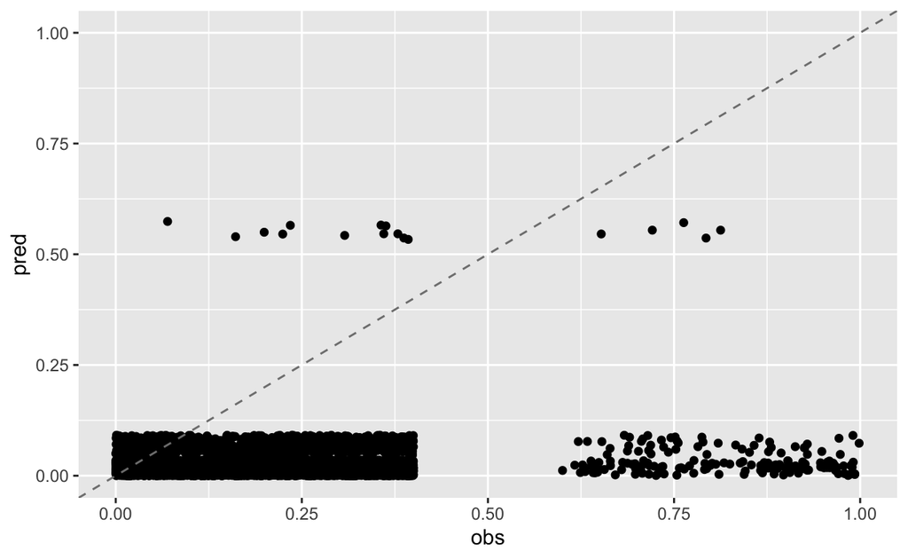

```r
#Plot predictions vs obs (v awkward to do since the outcome is binary)
obs <- hosp_test$exit_outcome
df  <- data.frame(pred, obs)

pred_plot <- ggplot(data = df) +
  geom_point(mapping = aes(x = obs, y = pred),position = "jitter") +
  geom_abline(lty = 2, color = "gray50") +
  #geom_hline(yintercept = 0, color = "gray50") +
  xlim(0,1) +
  ylim(0,1)
pred_plot
```

There wasn’t much space to tune this tree, since it’s so small. However, we still tried to search over a grid of hyperparameters to find the optimal tree.

```
[1] 1
```

```
[1] 16
```

```
  minsplit maxdepth
1        5        1
2        6        1
3        7        1
4        8        1
5        9        1
6       10        1
```

```
  minsplit maxdepth   cp     error
1        6        2 0.01 0.9706888
2        5        2 0.01 0.9714918
3        7        2 0.01 0.9723014
4        8        2 0.01 0.9735401
5        6        1 0.01 0.9753933
```

```
[1] 0.1208844
```

## REEM tree

We next tried a REEMtree model to see if it improved performance on panel data. This algorithm is designed to deal with longitudinal and clustered data, using a combination of mixed effects and tree-based models.

[figure not shown]

Our predicted test error from the REEMtree was slightly lower, at 11.7%.

```r
pred <- predict(REEMresult, hosp_test, EstimateRandomEffects=FALSE)
p_error <- Metrics::rmse(actual = hosp_test$exit_outcome, predicted = pred)
p_error
```

```
[1] 0.1166826
```

It was not obvious how to tune this model from the documentation, but we incorporated different types of autocorrelation. For example, with AR1 correlation, our test error is slightly higher at 11.9%.

```
[1] 0.1186809
```

## Random forest

The next step was to bag (and perturb) trees for a random forest. The out of the box RF gave us an 11.9% RMSE.

```r
#Create reproducible training (70%) and test (30%) sets.
cleaned <- select(hcris, -c(outcome_new,num_prvdr_num,cont,sysid))
cleaned <- select(cleaned, -c(162:216))

set.seed(123)
hosp_split <- initial_split(cleaned, prop = .7)
hosp_train <- training(hosp_split)
hosp_test  <- testing(hosp_split)

#number of features
n_features <- length(setdiff(names(hosp_train), "exit_outcome"))

#train a default random forest model
rf1 <- ranger(
  exit_outcome ~ .,
  data = hosp_train,
  mtry = floor(n_features / 3),
  respect.unordered.factors = "order",
  seed = 123,
)
rf1
```

```
Ranger result

Call:
 ranger(exit_outcome ~ ., data = hosp_train, mtry = floor(n_features/3),      respect.unordered.factors = "order", seed = 123, )

Type:                             Regression
Number of trees:                  500
Sample size:                      60068
Number of independent variables:  161
Mtry:                             53
Target node size:                 5
Variable importance mode:         none
Splitrule:                        variance
OOB prediction error (MSE):       0.01427203
R squared (OOB):                  0.09712428
```

```r
#RMSE
(default_rmse <- sqrt(rf1$prediction.error))
```

```
[1] 0.1194656
```

We tried tuning hyperparameters next, focusing on the number of trees, number of features considered, and tree complexity. A grid search suggested that a model with 1000 trees, 53 considered features, and a minimum node size of 20 performed best among the tested models.

```r
# create hyperparameter grid
hyper_grid.df <- expand.grid(
  num.trees = c(500, 1000),
  mtry = floor(n_features * c(.01, .05, .3333)),
  min.node.size = c(1, 10, 20),
  rmse = NA
)
```

```r
#create and register cluster
n.cores <- parallel::detectCores() - 1
my.cluster <- parallel::makeCluster(n.cores)
doParallel::registerDoParallel(cl = my.cluster)

#execute grid search in parallel
prediction.error <- foreach(
  num.trees     = hyper_grid.df$num.trees,
  mtry          = hyper_grid.df$mtry,
  min.node.size = hyper_grid.df$min.node.size,
  .combine = 'c',
  .packages = "ranger") %dopar% {

  #fit model
  m.i <- ranger::ranger(
    formula         = exit_outcome ~ .,
    data            = hosp_train,
    num.trees       = num.trees,
    mtry            = mtry,
    min.node.size   = min.node.size,
    verbose         = FALSE,
    seed            = 123,
    respect.unordered.factors = 'order'
  )

  #returning OOB error
  return(sqrt(m.i$prediction.error))
}

hyper_grid.df$prediction.error <- prediction.error

parallel::stopCluster(cl = my.cluster)
```

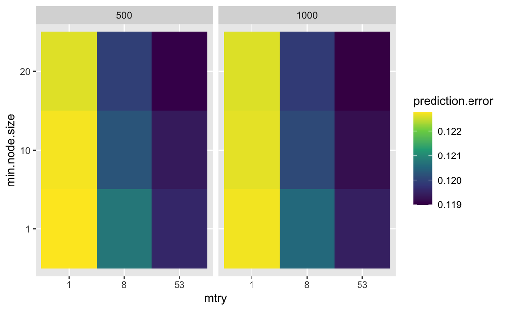

```r
#plot the errors
ggplot2::ggplot(data = hyper_grid.df) +
  ggplot2::aes(
    x = as.factor(mtry),
    y = as.factor(min.node.size),
    fill = prediction.error
  ) +
  ggplot2::facet_wrap(as.factor(hyper_grid.df$num.trees)) +
  ggplot2::geom_tile() +
  ggplot2::scale_y_discrete(breaks = c(1, 10, 20)) +
  ggplot2::scale_fill_viridis_c() +
  ggplot2::xlab("mtry") +
  ggplot2::ylab("min.node.size")
```

```r
#list top 10 models
hyper_grid.df %>%
  arrange(prediction.error) %>%
  head(10)
```

```
   num.trees mtry min.node.size rmse prediction.error
1       1000   53            20   NA        0.1189746
2        500   53            20   NA        0.1190613
3       1000   53            10   NA        0.1191950
4        500   53            10   NA        0.1193701
5       1000   53             1   NA        0.1194408
6        500   53             1   NA        0.1195574
7       1000    8            20   NA        0.1198683
8        500    8            20   NA        0.1199485
9       1000    8            10   NA        0.1200935
10       500    8            10   NA        0.1202625
```

Our tuned tree:

```r
#train a random forest model
rf1 <- ranger(
  exit_outcome ~ .,
  data = hosp_train,
  num.trees = 1000,
  mtry = floor(n_features / 3),
  respect.unordered.factors = "order",
  min.node.size = 20,
  seed = 123,
  importance = "permutation"
)
rf1
```

```
Ranger result

Call:
 ranger(exit_outcome ~ ., data = hosp_train, num.trees = 1000,      mtry = floor(n_features/3), respect.unordered.factors = "order",      min.node.size = 20, seed = 123, importance = "permutation")

Type:                             Regression
Number of trees:                  1000
Sample size:                      60068
Number of independent variables:  161
Mtry:                             53
Target node size:                 20
Variable importance mode:         permutation
Splitrule:                        variance
OOB prediction error (MSE):       0.01416719
R squared (OOB):                  0.1037566
```

```r
rf1$variable.importance
```

```
            year          tot_pop            white       highschool
    6.345895e-04     4.363609e-04     2.800357e-04     2.226910e-04
         college           unempl          med_inc          uninsur
    2.384035e-04     2.205135e-04     2.414556e-04     1.797502e-04
    public_insur    private_insur          elderly          poverty
    1.618546e-04     1.676801e-04     1.478556e-04     1.703761e-04
            male        mcaid_exp       wage_index            tacmi
    1.383622e-04     3.817122e-05     2.458087e-04     1.363640e-03
        age_hosp          age_sys            bdtot           admtot
    2.605401e-04     1.671630e-04     1.096134e-03     2.035006e-03
          ipdtot           paytot           exptot              fte
    1.165150e-03     1.795761e-03     2.005812e-03     1.511388e-03
           teach         catholic              cah       minorteach
    5.776135e-05     4.941800e-05     5.638321e-03     1.416554e-05
           rural            mcare            mcaid               vi
    7.626998e-06     5.920552e-04     1.167351e-04     8.302604e-07
    tot_services    tech_services      mh_services        bought_ss
    6.496821e-04     1.683418e-04     2.384603e-04    -3.367268e-06
          hsa_sh         hosp_hsa           hrr_sh         hosp_hrr
    1.165335e-03     1.017184e-04     8.230322e-04     2.066691e-04
       dist2hosp              occ          netdebt           uncomp
    3.116557e-04     1.163630e-04     6.540762e-04     1.311253e-03
             dsh        ptnt_opex        tot_costs          rev_tot
    6.221896e-03     3.059083e-03     1.824522e-03     3.384524e-03
     rev_netptnt       net_income      ptnt_income             cash
    3.569264e-03     5.035098e-03     7.769336e-04     4.792485e-04
            debt       tot_assets           fa_tot            capex
    5.372058e-04     1.112615e-03     2.389539e-03     6.790733e-04
          liquid          rev_adm             levg         ptnt_mgn
    1.310369e-04     3.134962e-04     1.353384e-03     5.126460e-04
          ni_mgn       uncomp_mgn        capex_mgn           bought
    4.619964e-03     6.723412e-05     1.453350e-04    -1.181705e-06
        sysowned        bought_is        absorbing            enter
    2.189509e-06    -1.345630e-06     0.000000e+00     8.689311e-06
          switch        switch2np           invest        n_boughts
   -1.427111e-06    -2.031103e-06     1.360477e-05     2.418866e-05
       age_enter    p_hist_invest  p_hist_downsize               fp
    2.119155e-04     9.962087e-05     1.616568e-04     8.060978e-05
              np              pub  hosp_type_child    hosp_type_gac
    3.558918e-06     4.313974e-06     1.907114e-05     1.189338e-04
```

[output cut: 27 more lines]

```
    2.780984e-05     3.841146e-06     1.667902e-05     2.719266e-05
      ch_tot_pop        ch_admtot       ch_netdebt     ch_ptnt_opex
    1.411938e-04     3.593937e-05     2.376331e-05     4.187307e-04
    ch_tot_costs       ch_rev_tot   ch_rev_netptnt    ch_net_income
    3.705875e-04     4.751481e-04     2.564536e-04     1.725089e-04
  ch_ptnt_income          ch_cash          ch_debt    ch_tot_assets
    7.164088e-05     1.209683e-05     2.522411e-04     2.862917e-04
        ch_capex       ch_rev_adm        ch_liquid          ch_levg
    4.100210e-05     5.008287e-05    -1.145564e-05     3.721818e-04
        ch_mcaid         ch_mcare ch_tech_services   ch_mh_services
    1.129932e-05     5.762649e-05     2.626638e-05     3.562106e-05
          ch_occ      ch_ptnt_mgn        ch_ni_mgn    ch_uncomp_mgn
    4.705837e-06     9.888506e-05     3.064087e-04     7.812048e-05
    ch_capex_mgn
    1.528029e-04
```

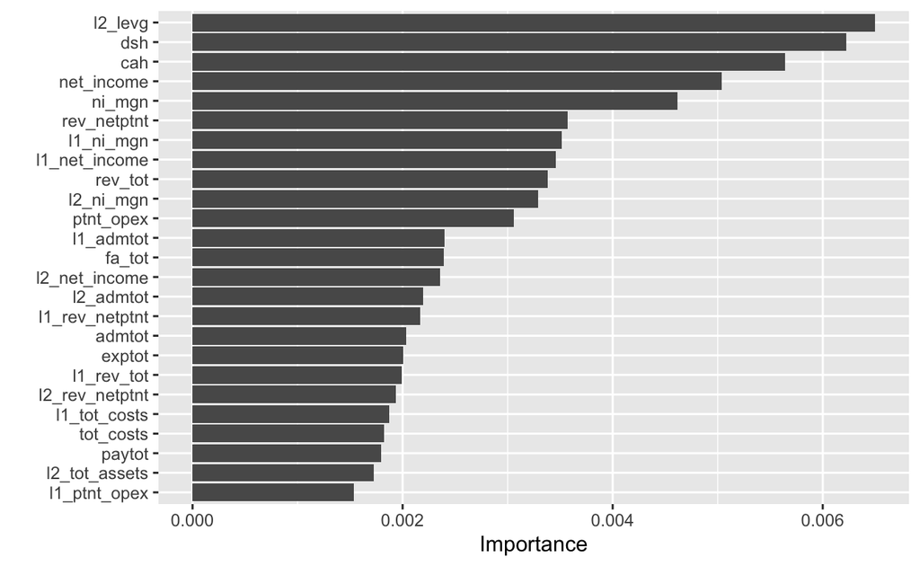

```r
p1 <- vip::vip(rf1, num_features = 25, bar = FALSE)
gridExtra::grid.arrange(p1, nrow = 1)
```

```r
#saved as varimptc.png

#RMSE
(default_rmse <- sqrt(rf1$prediction.error))
```

```
[1] 0.119026
```

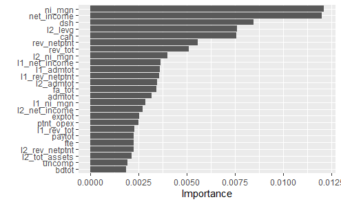

## Boosted trees

```r
detach("package:REEMtree", unload=TRUE)
library(xgboost)
cleaned <- dplyr::select(hcris, -c(outcome_new,num_prvdr_num,cont,sysid))
cleaned <- dplyr::select(cleaned, -c(162:216))

set.seed(123)
hosp_split <- initial_split(cleaned, prop = .7)
hosp_train <- training(hosp_split)
hosp_test  <- testing(hosp_split)
```

```
[1] 0.116286
```

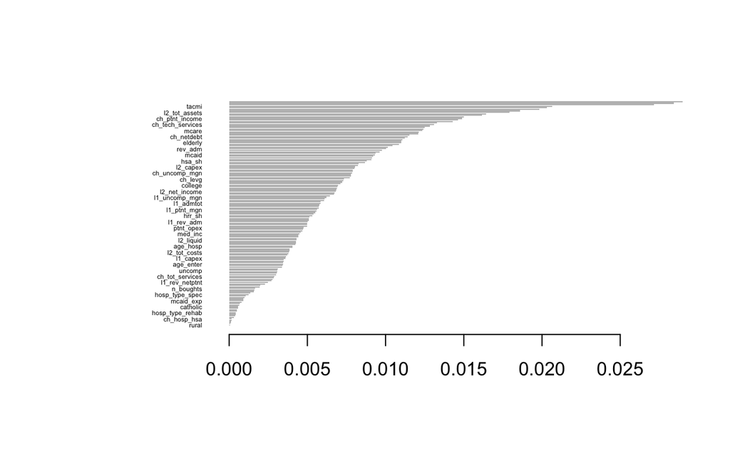

```
           Feature       Gain Importance
 1:      l2_ni_mgn 0.02900223 0.02900223
 2:           year 0.02843374 0.02843374
 3:        l2_levg 0.02715781 0.02715781
 4:          tacmi 0.02063461 0.02063461
 5:         ni_mgn 0.02032628 0.02032628
 6:  ch_tot_assets 0.01984236 0.01984236
 7: ch_rev_netptnt 0.01858822 0.01858822
 8:  l2_tot_assets 0.01791665 0.01791665
 9:        l1_cont 0.01640658 0.01640658
10:   l1_capex_mgn 0.01617720 0.01617720
```